# IE 425 Homework 2

Utku Atay

20 05 2020

## Question 1

The answer of the first question is in the pdf file.

## Question 2

```r
library(ISLR)
library(caTools)
library(class)
library(caret)
str(Default)
```

```
## 'data.frame':    10000 obs. of  4 variables:
##  $ default: Factor w/ 2 levels "No","Yes": 1 1 1 1 1 1 1 1 1 1 ...
##  $ student: Factor w/ 2 levels "No","Yes": 1 2 1 1 1 2 1 2 1 1 ...
##  $ balance: num  730 817 1074 529 786 ...
##  $ income : num  44362 12106 31767 35704 38463 ...
```

```r
set.seed(581)
Default$student <- as.numeric(Default$student)

scaled.Default = scale(Default[,c(-1)])

set.seed(581)
split = sample.split(1:10000,SplitRatio=0.7)

trainX = subset(scaled.Default,split==TRUE)
testX = subset(scaled.Default,split==FALSE)

trainY = subset(Default$default,split==TRUE)
testY = subset(Default$default,split==FALSE)

knn.pred.Default = NULL
error.rate = NULL

for(i in 1:10){
  set.seed(581)
  knn.pred.Default = knn(trainX,testX,trainY,k=i)
  error.rate[i] = mean(testY != knn.pred.Default)
}

print(error.rate)
```

```
##  [1] 0.04600000 0.04633333 0.03866667 0.03700000 0.03366667 0.03266667
##  [7] 0.03033333 0.03166667 0.02933333 0.02966667
```

```r
min.error.rate = min(error.rate)
print(min.error.rate)
```

```
## [1] 0.02933333
```

```r
num.Default = which(error.rate == min.error.rate)
print(num.Default)
```

```
## [1] 9
```

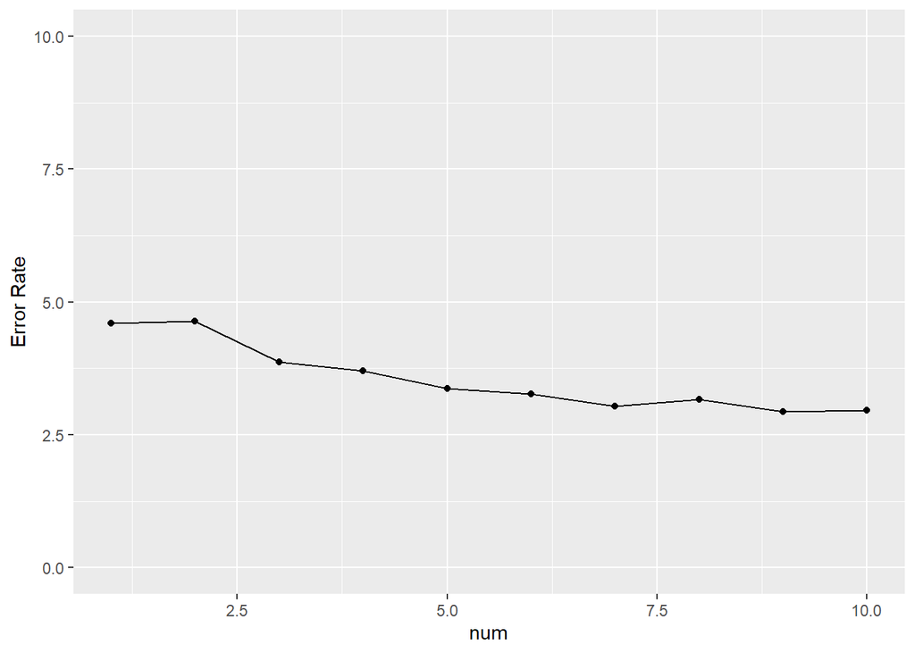

```r
library(ggplot2)
qplot(1:10, error.rate*100, xlab = "num", ylab = "Error Rate",ylim = c(0,10), geom=c("point", "line"))
```

```r
confusionMatrix(knn.pred.Default,testY)
```

```
## Confusion Matrix and Statistics
##
##           Reference
## Prediction   No  Yes
##        No  2875   78
##        Yes   11   36
##
##                Accuracy : 0.9703
##                  95% CI : (0.9636, 0.9761)
##     No Information Rate : 0.962
##     P-Value [Acc > NIR] : 0.007912
##
##                   Kappa : 0.4347
##
##  Mcnemar's Test P-Value : 2.634e-12
##
##             Sensitivity : 0.9962
##             Specificity : 0.3158
##          Pos Pred Value : 0.9736
##          Neg Pred Value : 0.7660
##              Prevalence : 0.9620
##          Detection Rate : 0.9583
##    Detection Prevalence : 0.9843
##       Balanced Accuracy : 0.6560
##
##        'Positive' Class : No
##
```

The accuracy for test set is 0.9703, therefore error rate is 0.0297, which is less than 3%. Sensetiviy is 0.9962 and Specificity is 0.3158.

## Question 3

### a)

```r
library(randomForest)
library(ISLR)
library(caTools)
library(class)
library(caret)

Toyota <- read.csv("C:/Users/user/Desktop/ToyotaCorolla.csv")
str(Toyota)
```

```
## 'data.frame':    1436 obs. of  10 variables:
##  $ Price    : int  13500 13750 13950 14950 13750 12950 16900 18600 21500 12950 ...
##  $ Age      : int  23 23 24 26 30 32 27 30 27 23 ...
##  $ KM       : int  46986 72937 41711 48000 38500 61000 94612 75889 19700 71138 ...
##  $ FuelType : Factor w/ 3 levels "CNG","Diesel",..: 2 2 2 2 2 2 2 2 3 2 ...
##  $ HP       : int  90 90 90 90 90 90 90 90 192 69 ...
##  $ MetColor : int  1 1 1 0 0 0 1 1 0 0 ...
##  $ Automatic: int  0 0 0 0 0 0 0 0 0 0 ...
##  $ CC       : int  2000 2000 2000 2000 2000 2000 2000 2000 1800 1900 ...
##  $ Doors    : int  3 3 3 3 3 3 3 3 3 3 ...
##  $ Weight   : int  1165 1165 1165 1165 1170 1170 1245 1245 1185 1105 ...
```

```r
set.seed(582)
split=sample.split(Toyota, SplitRatio=0.7)

train = subset(Toyota, split==TRUE)
test = subset(Toyota, split==FALSE)
```

### b)

We use “tuneRF” function to find near mtry value to optimal one. The we determined that optimal value is between 1 and 6. To find other optimal parameters, we looked the range 1-5 for nodeize parameter and 500-505 for ntree parameter.

```r
bag.toyota=randomForest(Price~.,data=train, importance=TRUE)
print(bag.toyota)
```

```
##
## Call:
##  randomForest(formula = Price ~ ., data = train, importance = TRUE)
##                Type of random forest: regression
##                      Number of trees: 500
## No. of variables tried at each split: 3
##
##           Mean of squared residuals: 1182232
##                     % Var explained: 90.69
```

```r
tuneRF(train[,-1], train$Price ,mtryStart = 1, ntreeTry = 500 , stepFactor = 2 , improve = 0.05)
```

```
## mtry = 1  OOB error = 2612185
## Searching left ...
## Searching right ...
## mtry = 2     OOB error = 1285241
## 0.5079825 0.05
## mtry = 4     OOB error = 1181612
## 0.08062939 0.05
## mtry = 8     OOB error = 1234225
## -0.04452585 0.05
```

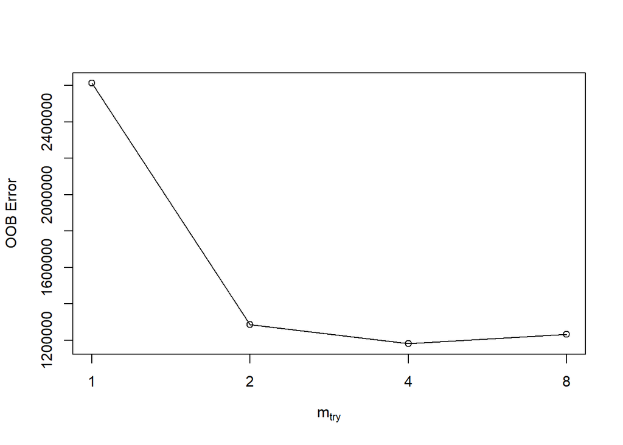

```
##   mtry OOBError
## 1    1  2612185
## 2    2  1285241
## 4    4  1181612
## 8    8  1234225
```

```r
#optimal mtry between 1-6
#optimal nodesize between 1-5
#ntree between 500-505

index = NULL
min.error = 99999

for(i in 1:6){
  for(j in 1:5){
    for(k in 500:505){
      set.seed(582)
      bag.toyota=randomForest(Price~.,data=train, mtry=i ,nodesize=j ,ntree=k, importance=TRUE)
      prediction = predict(bag.toyota, newdata = test)
      error = sqrt(mean(abs(prediction-test$Price )))
      if(min.error >= error) {
        min.error = error
        index= c(i, j, k)
        print(index)
      }
    }
  }
}
```

```
## [1]   1   1 500
## [1]   1   2 500
## [1]   1   2 501
## [1]   1   2 502
## [1]   1   2 503
## [1]   1   2 504
## [1]   1   4 500
## [1]   1   4 501
## [1]   1   4 502
## [1]   1   5 500
## [1]   1   5 501
## [1]   1   5 503
## [1]   1   5 504
## [1]   2   1 500
## [1]   2   1 505
```

[output cut: 19 more lines]

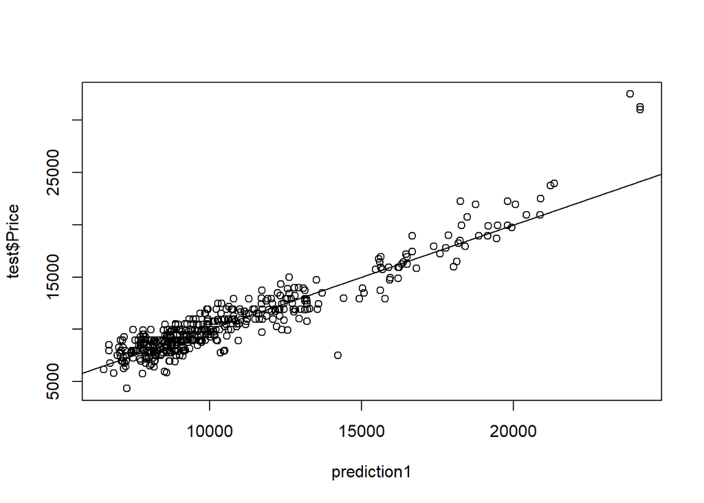

```r
set.seed(582)
bag.toyota1 =randomForest(Price~.,data=train, mtry=4 ,nodesize=5 ,ntree=500, importance=TRUE)
prediction1 = predict(bag.toyota1, newdata = test)

plot(prediction1, test$Price)
abline(0,1)
```

### c)

In the importance function, there are two types measures: percentage increase in mean square error and increase in node purity. - Percentage increase in mean square error is analogous to accuracy-based importance, and is calculated by shuffling the values of the out-of-bag samples. - Increase in node purity is analogous to Gini-based importance, and is calculated based on the reduction in sum of squared errors whenever a variable is chosen to split.

```r
set.seed(582)
import <-round(importance(bag.toyota1),2)
import
```

```
##           %IncMSE IncNodePurity
## Age         78.40    7495511511
## KM          24.15    2563115288
## FuelType     4.76      80479306
## HP          14.17     461534125
## MetColor     5.42      56564842
## Automatic    4.44      17964135
## CC          16.89     233742716
## Doors       15.47      75192945
## Weight      25.76    1603933862
```

```r
rank(-import[,1])
```

```
##       Age        KM  FuelType        HP  MetColor Automatic        CC     Doors
##         1         3         8         6         7         9         4         5
##    Weight
##         2
```

```r
rank(-import[,2])
```

```
##       Age        KM  FuelType        HP  MetColor Automatic        CC     Doors
##         1         2         6         4         8         9         5         7
##    Weight
##         3
```

According to percentage in mean square error, the most 3 important variable is Age, Weight, KM respectively. However, increase in node purity method states that most important variable is Age, second and third variable are KM and weight respectively. Positions of KM and Weight variables are changed between those methods.